# 04_rect_to_polar

## 04_rect_to_polar

#### Question

1. A point on a Cartesian plane is given in [rectangular coordinates](https://en.wikipedia.org/wiki/Cartesian_coordinate_system):
   $$x = -3.86$$
   $$y=-1.6$$

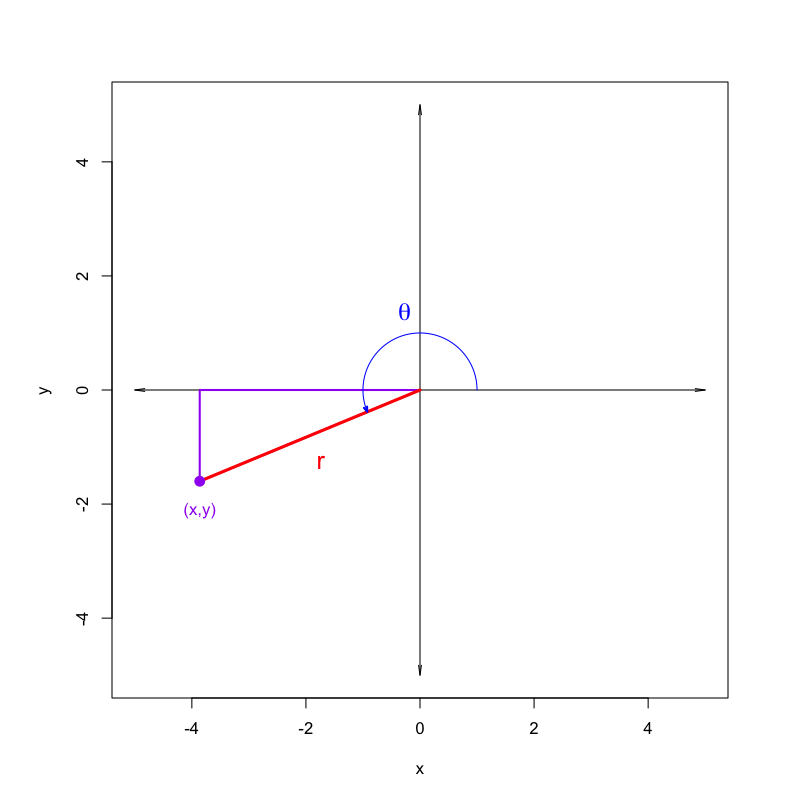

   Please determine the polar coordinates ($r$ and $\theta$), enforcing $0\le\theta<2\pi$.
   - The radius: $r=$
   - The angle: $\theta=$

#### Question

2. A point on a Cartesian plane is given in [rectangular coordinates](https://en.wikipedia.org/wiki/Cartesian_coordinate_system):
   $$x = 4.49$$
   $$y=-2.36$$

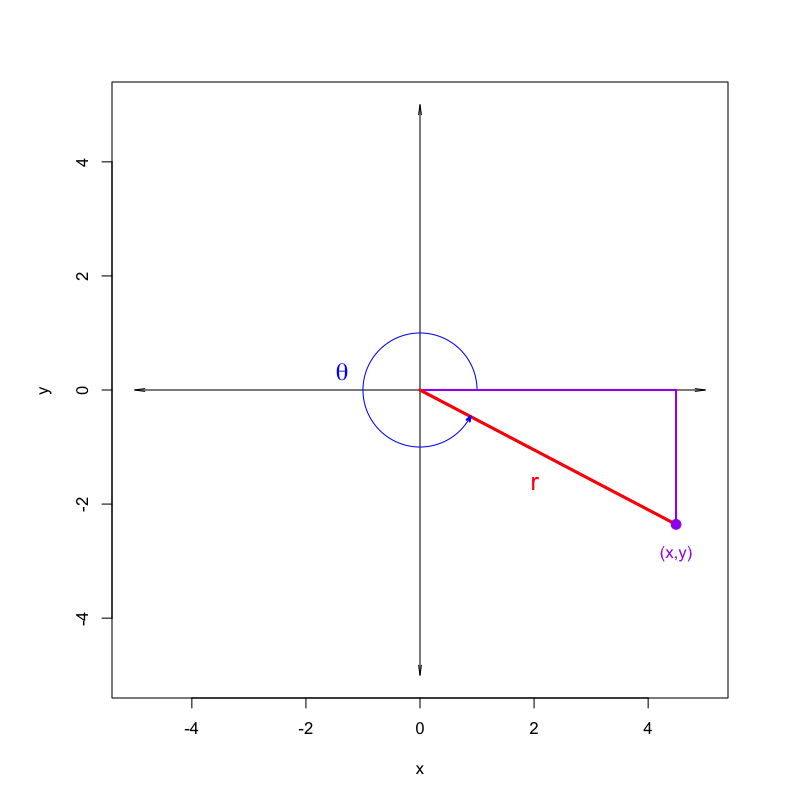

   Please determine the polar coordinates ($r$ and $\theta$), enforcing $0\le\theta<2\pi$.
   - The radius: $r=$
   - The angle: $\theta=$

#### Question

3. A point on a Cartesian plane is given in [rectangular coordinates](https://en.wikipedia.org/wiki/Cartesian_coordinate_system):
   $$x = 3.56$$
   $$y=-1.87$$

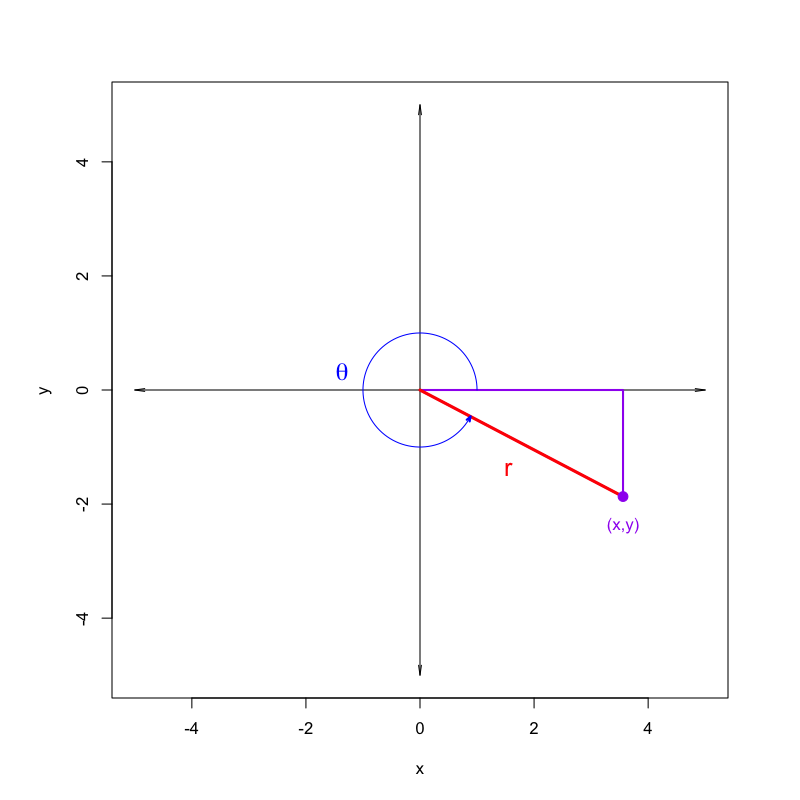

   Please determine the polar coordinates ($r$ and $\theta$), enforcing $0\le\theta<2\pi$.
   - The radius: $r=$
   - The angle: $\theta=$

#### Question

4. A point on a Cartesian plane is given in [rectangular coordinates](https://en.wikipedia.org/wiki/Cartesian_coordinate_system):
   $$x = -4.02$$
   $$y=-1.94$$

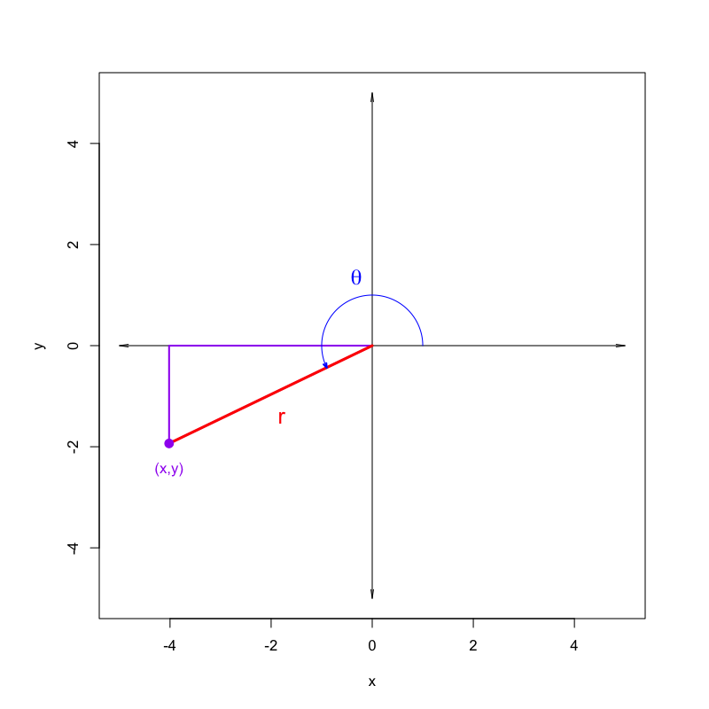

   Please determine the polar coordinates ($r$ and $\theta$), enforcing $0\le\theta<2\pi$.
   - The radius: $r=$
   - The angle: $\theta=$

#### Question

5. A point on a Cartesian plane is given in [rectangular coordinates](https://en.wikipedia.org/wiki/Cartesian_coordinate_system):
   $$x = -3.25$$
   $$y=4.08$$

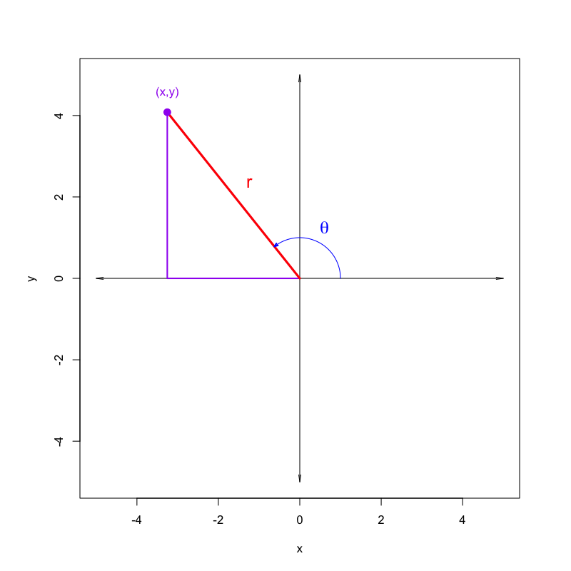

   Please determine the polar coordinates ($r$ and $\theta$), enforcing $0\le\theta<2\pi$.
   - The radius: $r=$
   - The angle: $\theta=$

#### Question

6. A point on a Cartesian plane is given in [rectangular coordinates](https://en.wikipedia.org/wiki/Cartesian_coordinate_system):
   $$x = 3.27$$
   $$y=-1.89$$

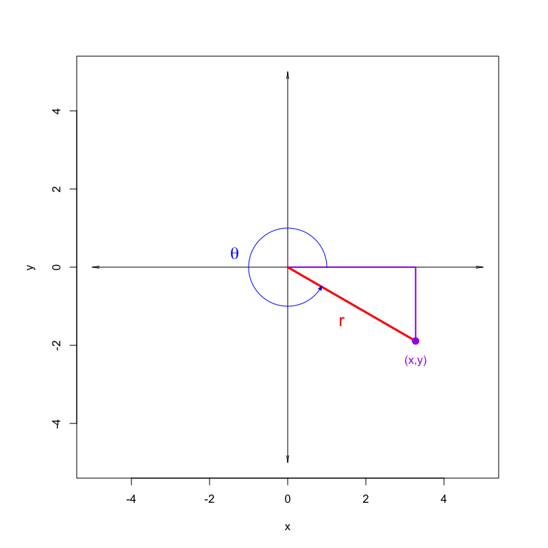

   Please determine the polar coordinates ($r$ and $\theta$), enforcing $0\le\theta<2\pi$.
   - The radius: $r=$
   - The angle: $\theta=$

#### Question

7. A point on a Cartesian plane is given in [rectangular coordinates](https://en.wikipedia.org/wiki/Cartesian_coordinate_system):
   $$x = -3.4$$
   $$y=-2.71$$

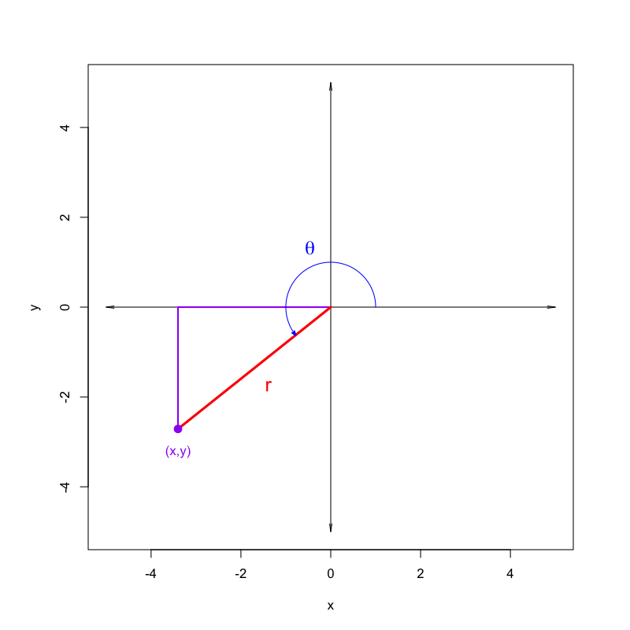

   Please determine the polar coordinates ($r$ and $\theta$), enforcing $0\le\theta<2\pi$.
   - The radius: $r=$
   - The angle: $\theta=$

#### Question

8. A point on a Cartesian plane is given in [rectangular coordinates](https://en.wikipedia.org/wiki/Cartesian_coordinate_system):
   $$x = -1.51$$
   $$y=-3.13$$

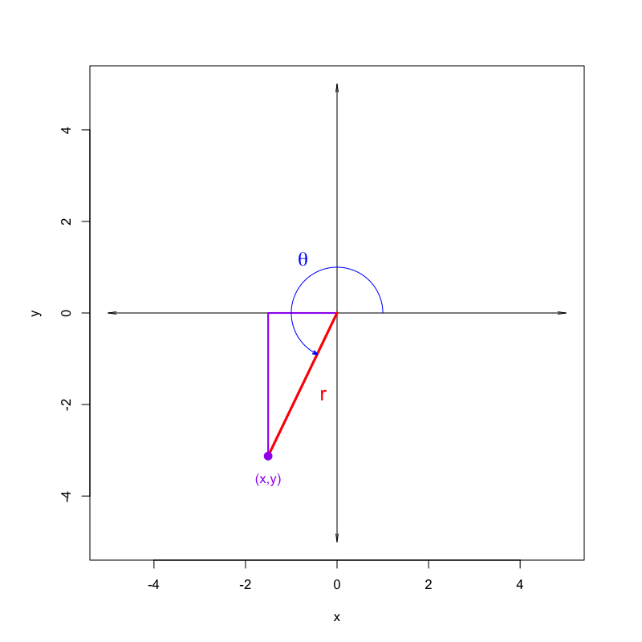

   Please determine the polar coordinates ($r$ and $\theta$), enforcing $0\le\theta<2\pi$.
   - The radius: $r=$
   - The angle: $\theta=$